# Lecture 04: Probability and Inference

Author

Bill Perry

# **Lecture 4: Probability and Statistical Inference**

- Review of probability distributions
- Standard normal distribution and Z-scores
- Standard error and confidence intervals
- Statistical inference fundamentals
- Hypothesis testing principles

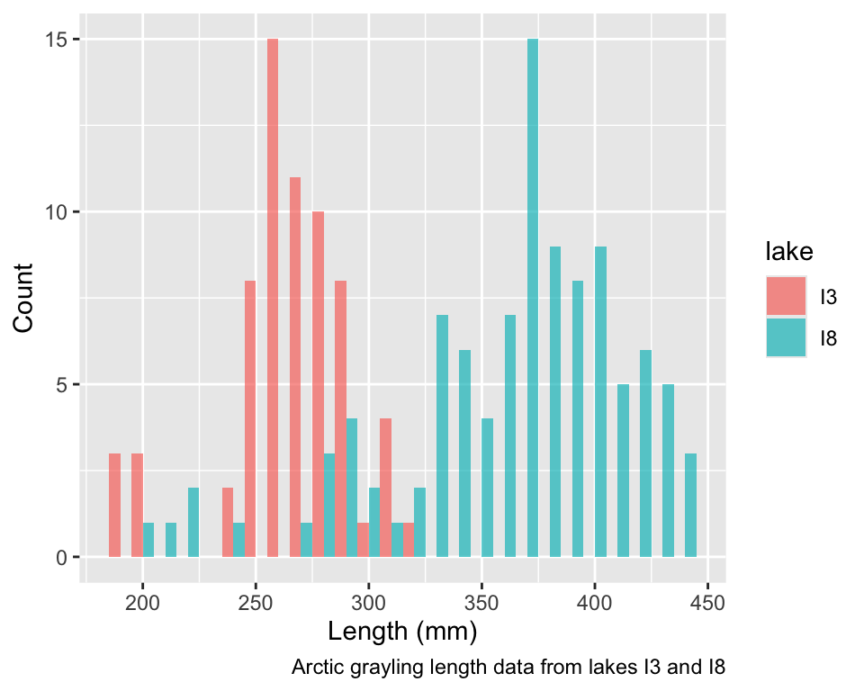

# Practice Exercise 1: Exploring the Grayling Dataset

**Practice Exercise 1: Exploring the Grayling Dataset**

Let’s explore the Arctic grayling data from lakes I3 and I8. Use the `grayling_df` data frame to create basic summary statistics.

```r
# Write your code here to explore the basic structure of the data
# also note plottig a box plot is really useful


# Calculate summary statistics
grayling_summary <- grayling_df %>%
  group_by(lake) %>%
  summarize(
    mean_length = mean(length_mm, na.rm = TRUE),
    sd_length = sd(length_mm, na.rm = TRUE),
    se_length = sd_length/sqrt(sum(!is.na(length_mm))),
    count = sum(!is.na(length_mm)),
    .groups = "drop")
grayling_summary
```

```
# A tibble: 2 × 5
  lake  mean_length sd_length se_length count
  <chr>       <dbl>     <dbl>     <dbl> <int>
1 I3           266.      28.3      3.48    66
2 I8           363.      52.3      5.18   102
```

# **Lecture 4:** Probability Distributions

## Probability Distribution Functions

- A **probability distribution** describes the probability of different outcomes in an experiment
- We’ve seen histograms of observed data
- Theoretical distributions help us model and understand real-world data
- We will focus on a **standard normal distribution** and a **students** **t distribution**

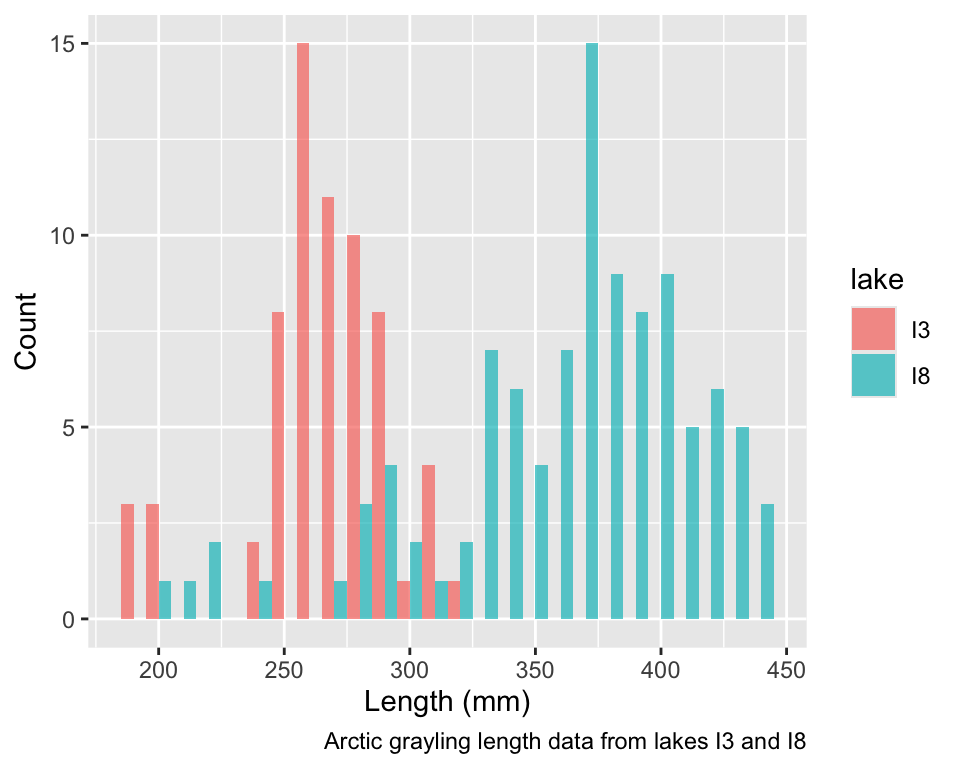

# **Lecture 4:** The Standard Normal Distribution

The standard normal distribution is crucial for understanding statistical inference:

- Has mean (μ) = 0 and standard deviation (σ) = 1
- Symmetrical bell-shaped curve
- Area under the curve = 1 (total probability)
- **Approximately**:
  - 68% of data within ±1σ of the mean
  - **95% of data within ±2σ of the mean - really 1.96σ**
  - 99.7% of data within ±3σ of the mean

Z-scores allow us to convert any **normal distribution** to the **standard normal distribution.**

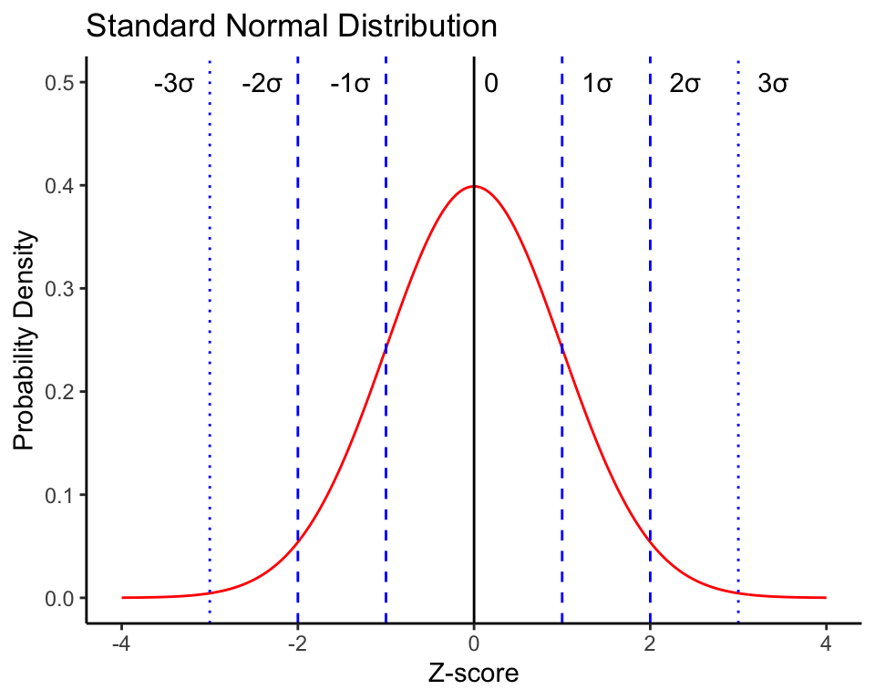

# Practice Exercise 2: Calculating Z-scores of lake I3

**Practice Exercise 2: Calculating Z-scores**

Let’s practice converting raw values to Z-scores using the Arctic grayling data.

**Z Score = (length - mean) / standard deviation**

```r
# Calculate the mean and standard deviation of fish lengths
mean_length <- mean(i3_df$length_mm, na.rm = TRUE)
sd_length <- sd(i3_df$length_mm, na.rm = TRUE)

# Calculate Z-scores for fish lengths
i3_df <- i3_df %>%
  mutate(z_score = (length_mm - mean_length) / sd_length)

# View the first few rows with Z-scores
head(i3_df)
```

```
# A tibble: 6 × 6
   site lake  species         length_mm mass_g z_score
  <dbl> <chr> <chr>               <dbl>  <dbl>   <dbl>
1   113 I3    arctic grayling       266    135  0.0139
2   113 I3    arctic grayling       290    185  0.862
3   113 I3    arctic grayling       262    145 -0.127
4   113 I3    arctic grayling       275    160  0.332
5   113 I3    arctic grayling       240    105 -0.905
6   113 I3    arctic grayling       265    145 -0.0214
```

# **Lecture 4:** The fish data as a z score

So if we plot this data what does it look like in a standard normal distributon?

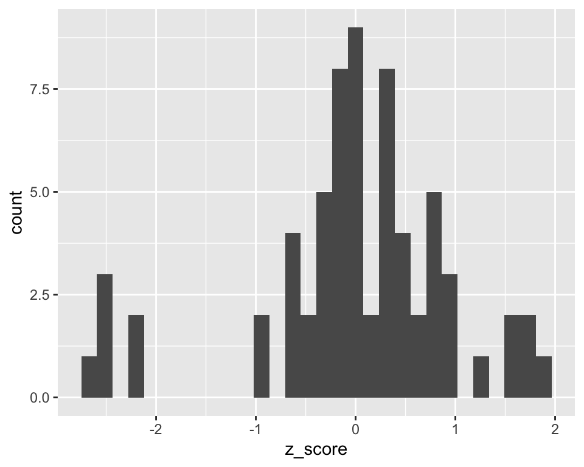

# Z-score Results

### How to get area under 1 STD DEV?

Proportion within 1 standard deviation = sum of absolute values of Z Scores that are less than or equal to 1 divided by the number in the sample…

Remember in a true normal distribution it is 68% within 1 std dev.

should be **approximately (varies if distribution is not normal)**:

- 68% of data within ±1σ of the mean
- **95% of data within ±2σ of the mean - really 1.96σ**
- 99.7% of data within ±3σ of the mean

```r
# What proportion of fish are within 1 standard deviation of the mean?
within_1sd <- sum(abs(i3_df$z_score) <= 1, na.rm = TRUE) / sum(!is.na(i3_df$z_score))
cat("Proportion within 1 SD:", round(within_1sd * 100, 1), "%\n")
```

```
Proportion within 1 SD: 81.8 %
```

# Lecture 4: Standard normal distribution - Fish Data

You want to know things about this population like

- probability of a fish having a certain length (e.g., > 300 mm)
- Can solve this by integrating the area under curve
- But it is tedious to do every time
- Instead
  - we can use the *standard normal distribution* (SND)
  - and can use the proportions from the density curve

```
# A tibble: 1 × 1
  mean_length
        <dbl>
1        266.
```

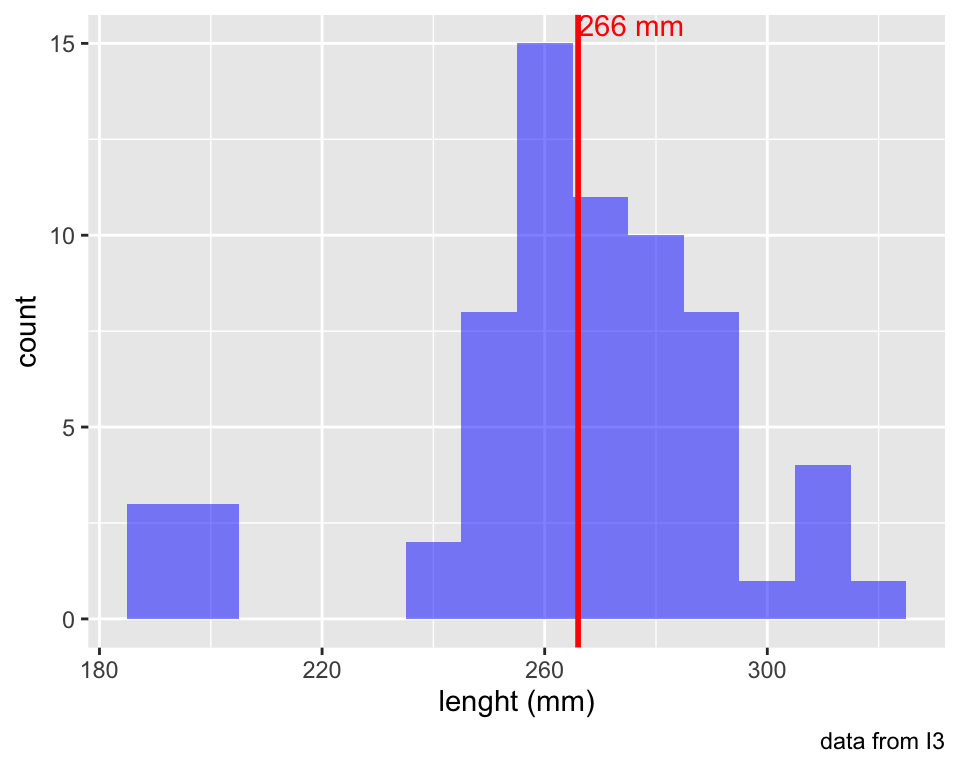

# Lecture 4: Standard normal distribution properties

Standard Normal Distribution

- “benchmark” normal distribution with µ = 0, σ = 1
- The Standard Normal Distribution is defined so that:
  - ~68% of the curve area within +/- 1 σ of the mean,
  - ~95% within +/- 2 σ of the mean,
  - ~99.7% within +/- 3 σ of the mean

*remember σ = standard deviation

# Lecture 4: Using Z-tables

Areas under curve of Standard Normal Distribution

- Have been calculated for a range of sample sizes
- Can be looked up in z-table
- No need to integrate
- Any normally distributed data can be standardized
  - transformed into the standard normal distribution
  - a value can be looked up in a table

# Lecture 4: Z-score Formula

Done by converting original data points to z-scores

- Z-scores calculated as:

## $\text{Z = }\frac{x_i-\mu}{\sigma}$

- z = z-score for observation
- xi = original observation
- µ = mean of data distribution
- σ = SD of data distribution

So lets do this for a fish that is 300mm long and guess the probability of catching something larger

z = (300 - 265.61)/28.3 = 1.215194

# Lecture 4: Z-score example from table

Done by converting original data points to z-scores

- Z-scores calculated as:

## $\text{Z = }\frac{X_i-\mu}{\sigma}$

- z = z-score for observation
- xi = original observation
- µ = mean of data distribution
- σ = SD of data distribution

So lets do this for a fish that is 300mm long and guess the probability of catching something larger

**At what point do you think its not likely to catch a larger fish - what percentage?**

do this the other way using that percent and why?

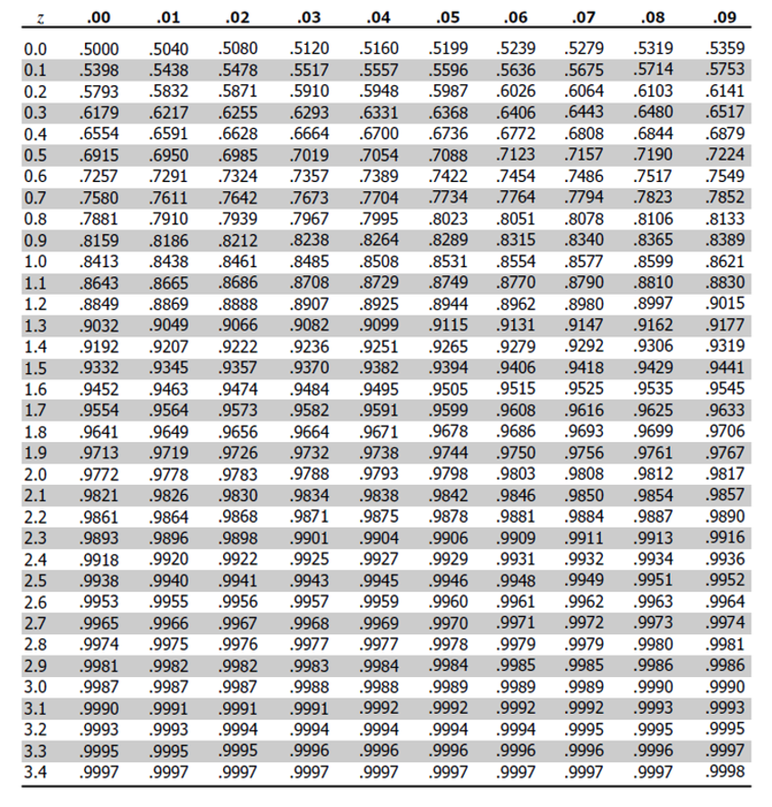

# Lecture 4: Z-score example calculation in r

We can use R to get these values easier…

# For standard normal distribution (mean=0, sd=1):

- pnorm(z) # gives cumulative probability (area to the left)
- qnorm(p) # gives z-value for a given probability
- dnorm(z) # gives probability density

```r
# Examples:
z_value <-  1.22
prob_left <- pnorm(z_value)          # 0.975 (97.5% to the left)
prob_right <- 1 - pnorm(z_value)     # 0.025 (2.5% to the right)
prob_between <- pnorm(2) - pnorm(-2)  # 0.95 (95% between ±1.96)
# To find z-value for a given probability:
z_for_95_percent <- qnorm(0.888)     # 1.96
print(prob_left)
```

```
[1] 0.8887676
```

```r
print(prob_right)
```

```
[1] 0.1112324
```

```r
print(prob_between)
```

```
[1] 0.9544997
```

```r
print(z_for_95_percent)
```

```
[1] 1.21596
```

# Lecture 4: We can now use this for fun in the fish

Lets say we are interested in knowing at what point from I3 it is not likely to catch a larger fish?

Maybe we expect 95% of the time to catch a fish that is “common” but the 5% is the unlikely portion….

```r
# Examples:
# What fish length corresponds to the top 5% (unlikely)?
top_5_percent_z <- qnorm(0.95)  # z-score for 95th percentile
unlikely_length <- mean_length + (top_5_percent_z * sd_length)

cat("Only 5% of fish are longer than:", round(unlikely_length, 1), "mm\n")
```

```
Only 5% of fish are longer than: 312.2 mm
```

```r
cat("This corresponds to z-score:", round(top_5_percent_z, 3), "\n")
```

```
This corresponds to z-score: 1.645
```

# Lecture 4: What this means

Given that we can: transform data to z-scores from standard normal distribution…

…figure out area under the curve (probability) associated with range of z-scores…

…can therefore figure out probability associated with a range of original data

# Lecture 4: So what is next…

We can look at Standard normal distributions and know probability of a value being in a range under the standard normal curve…

Previously we had calculated Standard Error and Confidence Intervals -

- Now can assess our confidence that the population mean is within a certain range
- Can use t distribution to ask questions like:
  - “What is probability of getting sample with mean = ȳ from population with mean = µ?“ (1 sample t-test)
  - “What is the probability that two samples came from same population?” (2 sample t-test)

# **Lecture 4:** When Population σ is Unknown

### When calculating confidence intervals we usually DON’T know the population σ (standard deviation) or 𝝁 population mean

- estimate it from the samples when don’t know the population σ or 𝝁
- and when sample size is small < ~30
- can’t use the standard normal (z) distribution

*Instead, we use Student’s t distribution*

[figure not shown]

# **Lecture 4:** Understanding t-distribution

### When sample sizes are small, the **t-distribution** is more appropriate than the normal distribution.

- Similar to normal distribution but with heavier tails
- Shape depends on **degrees of freedom** (df = n-1)
- With large df (>30), approaches the normal distribution
- Used for:
  - Small sample sizes
  - When population standard deviation is unknown
  - Calculating confidence intervals
  - Conducting t-tests

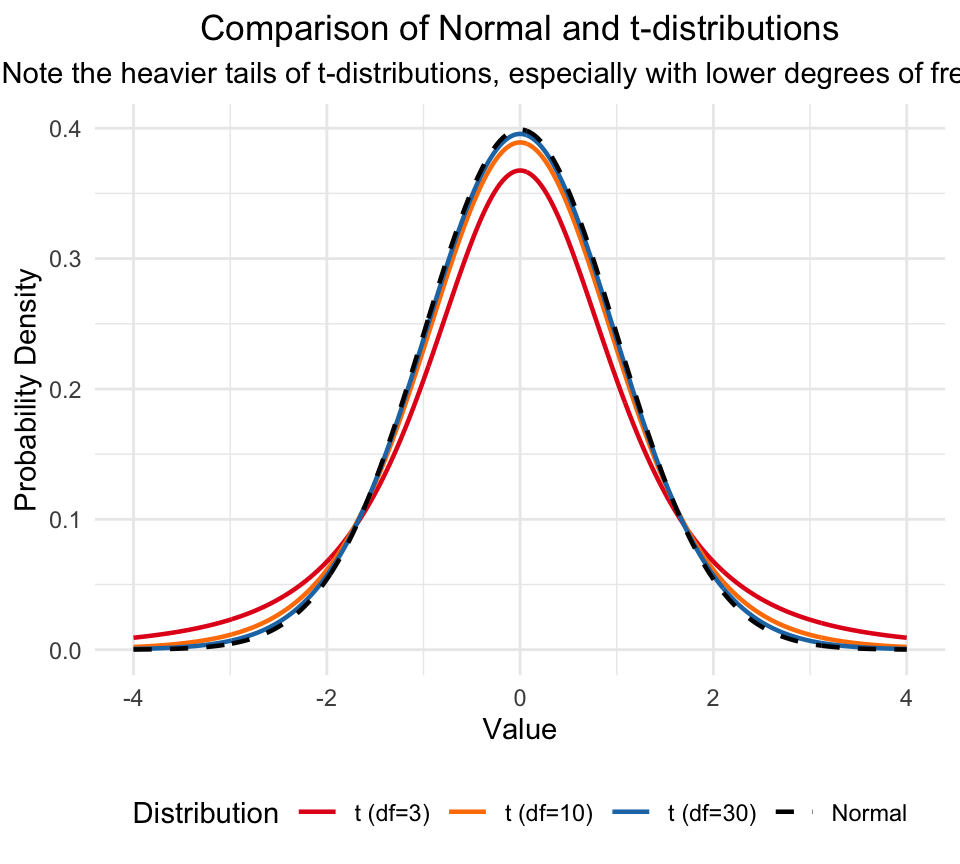

# Student’s t-distribution Formula

### To calculate CI for sample from “unknown” population:

## $\text{CI} = \bar{y} \pm t \cdot \frac{s}{\sqrt{n}}$

Where:

- ȳ is sample mean
- 𝑛 is sample size
- s is sample standard deviation
- t t-value corresponding the probability of the CI
- t in t-table for different degrees of freedom (n-1)

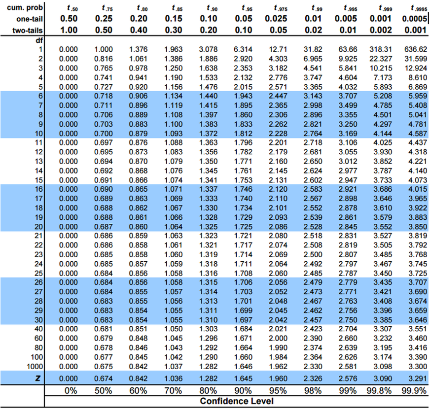

# **Lecture 4:** Student’s t-distribution Table

### Here is a t-table

- Values of t that correspond to probabilities
- Probabilities listed along top
- Sample dfs are listed in the left-most column
- Probabilities are given for one-tailed and two-tailed “questions”

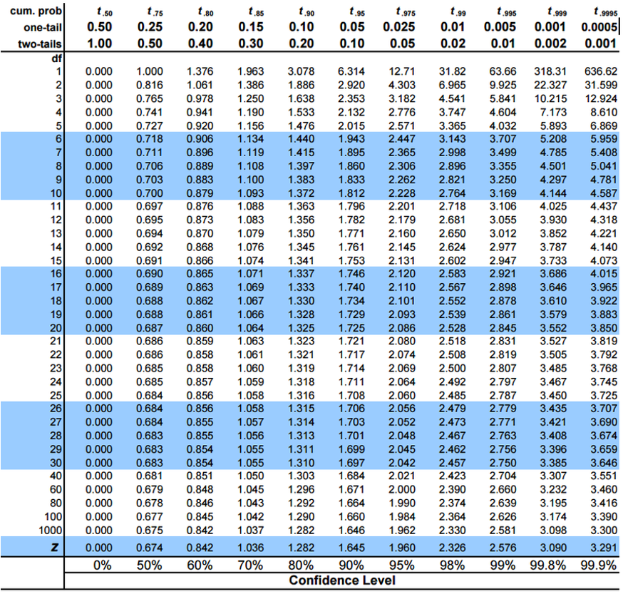

# **Lecture 4:** One-tailed Questions

### One-tailed questions: area of distribution left or (right) of a certain value

- n=20 (df=19) - 90% of the observations found left
- t= 1.328 (10% are outside)

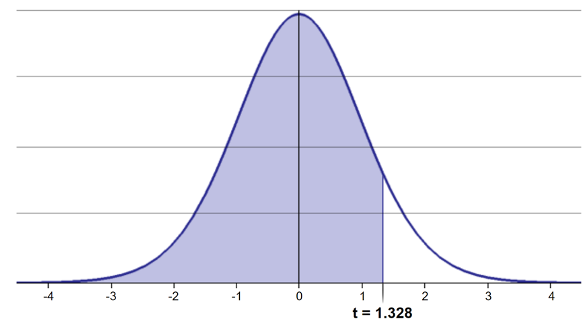

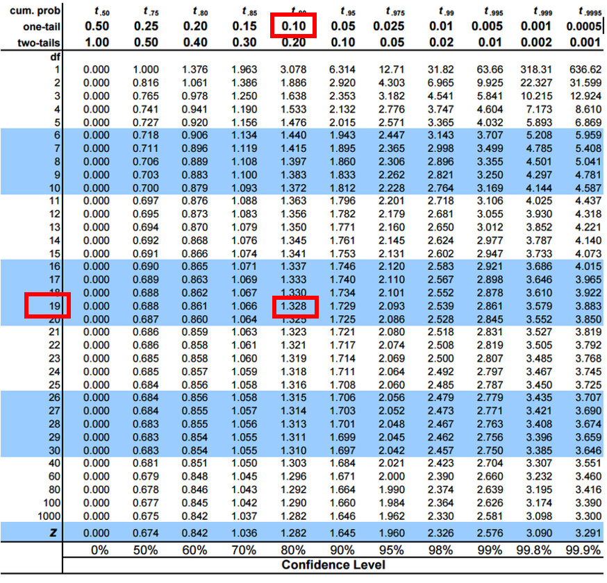

# **Lecture 4:** Two-tailed Questions

Two-tailed questions refer to area between certain values

- n= 20 (df=19), 90% of the observations are between
- t=-1.729 and t=1.729 (10% are outside)

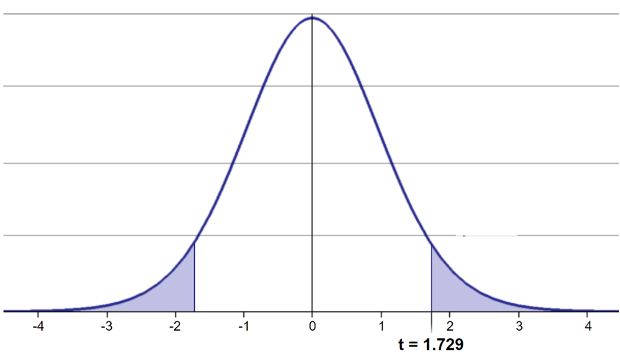

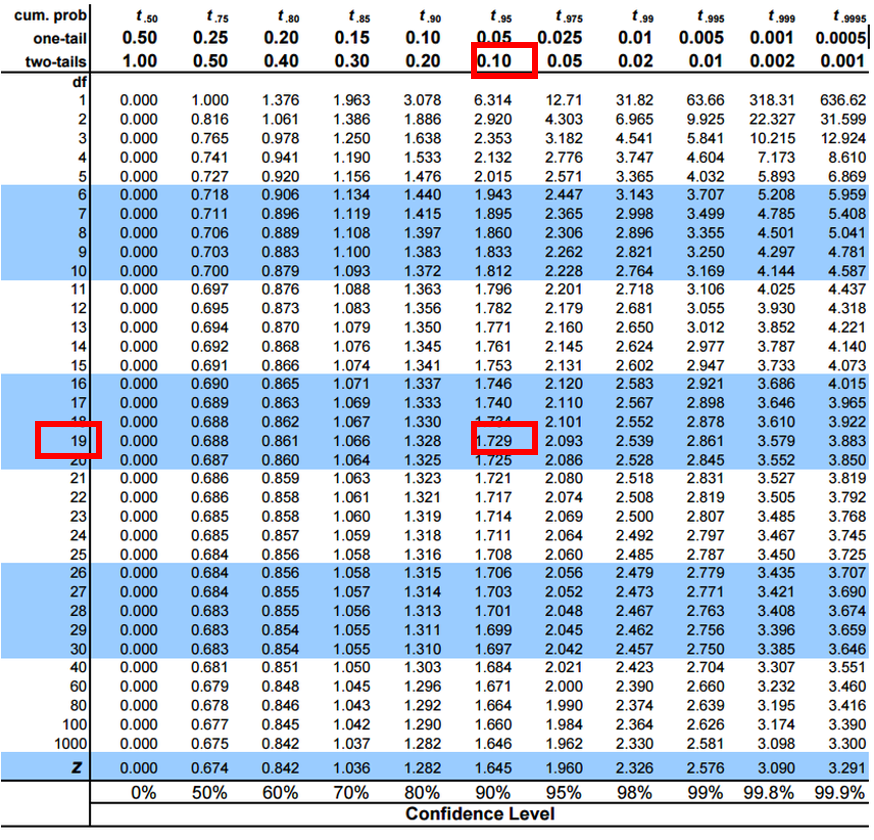

# **Lecture 4:** t-distribution CI Example

Let’s calculate CIs again:

Use two-sided test

## $\text{CI} = \bar{y} \pm t \cdot \frac{s}{\sqrt{n}}$

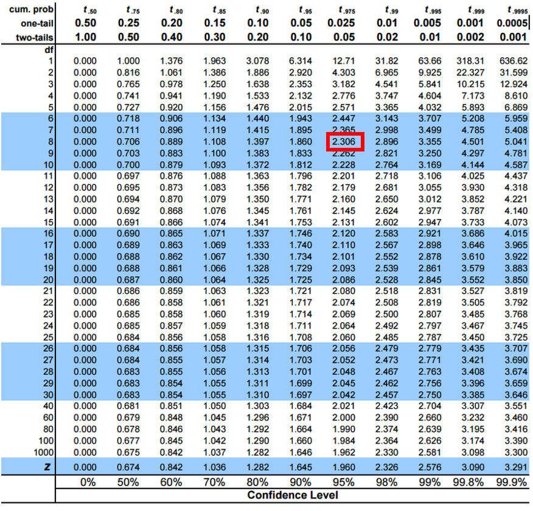

# Practice Exercise 4: Using the t-distribution

**Practice Exercise 4: Using the t-distribution**

## $\text{CI} = \bar{y} \pm t \cdot \frac{s}{\sqrt{n}}$

**Practice Exercise 4: Using the t-distribution**

## $\text{CI} = \bar{y} \pm t \cdot \frac{s}{\sqrt{n}}$

```r
# Display results
cat("Mean:", round(sample_mean, 1), "mm\n")
```

```
Mean: 276.3 mm
```

```r
cat("Standard deviation:", round(sample_sd, 2), "mm\n")
```

```
Standard deviation: 26.73 mm
```

```r
cat("Standard error:", round(sample_se, 2), "mm\n")
```

```
Standard error: 8.45 mm
```

```r
cat("95% CI using z:", round(z_ci_lower, 1), "to", round(z_ci_upper, 1), "mm\n")
```

```
95% CI using z: 259.7 to 292.9 mm
```

```r
cat("95% CI using t:", round(t_ci_lower, 1), "to", round(t_ci_upper, 1), "mm\n")
```

```
95% CI using t: 257.2 to 295.4 mm
```

```r
cat("t critical value:", round(t_crit, 3), "vs z critical value: 1.96\n")
```

```
t critical value: 2.262 vs z critical value: 1.96
```

# **Lecture 4:** Intro to Hypothesis Testing one tailed

Hypothesis testing is a systematic way to evaluate research questions using data.

**Key components:**

1. **Null hypothesis (H₀)**: Typically assumes “no effect” or “no difference”
2. **Alternative hypothesis (Hₐ)**: The claim we’re trying to support
3. **Statistical test**: Method for evaluating evidence against H₀
4. **P-value**: Probability of observing our results (or more extreme) if H₀ is true
5. **Significance level (α)**: Threshold for rejecting H₀, typically 0.05

```
Summary of One-Tailed Hypothesis Test:
```

```
Sample mean: 320
```

```
Hypothesized mean: 285
```

```
Sample size: 12
```

```
Standard deviation: 42.15
```

```
Standard error: 12.168
```

```
t-statistic: 2.876
```

```
Critical t-value (one-tailed): 1.796
```

```
Critical value: 306.85
```

```
Decision: Reject Ho (sample mean falls in upper rejection region)
```

# **Lecture 4:** Intro to Hypothesis Testing one tailed

Hypothesis testing is a systematic way to evaluate research questions using data.

**Key components:**

1. **Null hypothesis (H₀)**: Typically assumes “no effect” or “no difference”
2. **Alternative hypothesis (Hₐ)**: The claim we’re trying to support
3. **Statistical test**: Method for evaluating evidence against H₀
4. **P-value**: Probability of observing our results (or more extreme) if H₀ is true
5. **Significance level (α)**: Threshold for rejecting H₀, typically 0.05

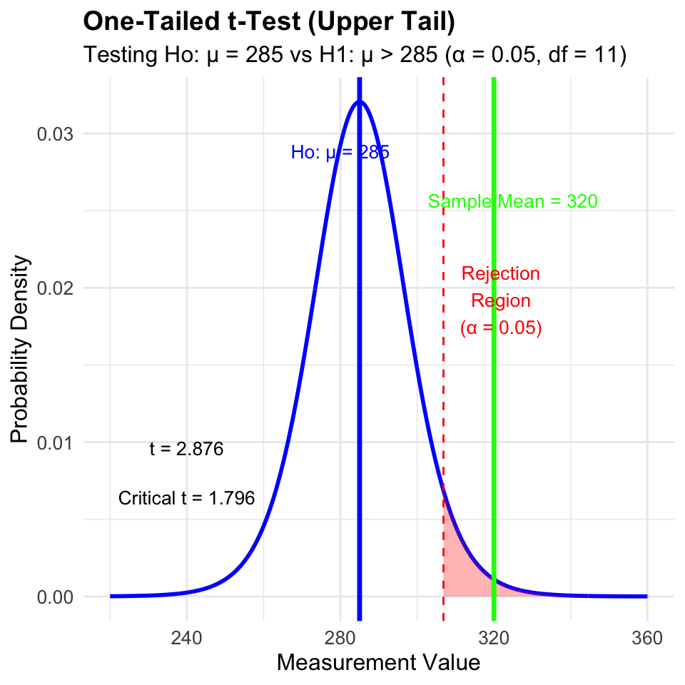

# **Lecture 4:** Hypothesis Testing two tailed

Hypothesis testing is a systematic way to evaluate research questions using data.

**Key components:**

1. **Null hypothesis (H₀)**: Typically assumes “no effect” or “no difference”
2. **Alternative hypothesis (Hₐ)**: The claim we’re trying to support
3. **Statistical test**: Method for evaluating evidence against H₀
4. **P-value**: Probability of observing our results (or more extreme) if H₀ is true
5. **Significance level (α)**: Threshold for rejecting H₀, typically 0.05

**Decision rule**: Reject H₀ if p-value < α

lets test if our sample mean of 320 is equal to 270 or not? Essentially we are looking at the confidence intervals!!!

```
Summary of Hypothesis Test:
```

```
Sample mean: 320
```

```
Hypothesized mean: 270
```

```
Standard error: 12.603
```

```
t-statistic: 3.967
```

```
Critical t-value (±): 2.306
```

```
Critical values: 240.94 to 299.06
```

```
Decision: Reject Ho (sample mean falls in rejection region)
```

# **Lecture 4:** Hypothesis Testing two tailed

Hypothesis testing is a systematic way to evaluate research questions using data.

**Key components:**

1. **Null hypothesis (H₀)**: Typically assumes “no effect” or “no difference”
2. **Alternative hypothesis (Hₐ)**: The claim we’re trying to support
3. **Statistical test**: Method for evaluating evidence against H₀
4. **P-value**: Probability of observing our results (or more extreme) if H₀ is true
5. **Significance level (α)**: Threshold for rejecting H₀, typically 0.05

**Decision rule**: Reject H₀ if p-value < α

lets test if our sample mean of 320 is equal to 270 or not? Essentially we are looking at the confidence intervals!!!

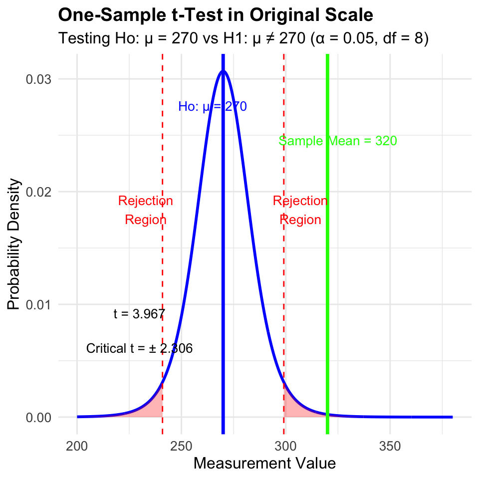

# Practice Exercise 5: One-Sample t-Test

**Practice Exercise 5: Lets practice a One-Sample t-Test**

Let’s perform a one-sample t-test to determine if the mean fish length in Lake I3 differs from 260 mm:

```r
# get only lake I3
i3_df <- grayling_df %>% filter(lake=="I3")

# what is the mean
i3_mean <- mean(i3_df$length_mm, na.rm=TRUE)
cat("Mean:", round(i3_mean, 1), "mm\n")
```

```
Mean: 265.6 mm
```

```r
# Perform a one-sample t-test
t_test_result <- t.test(i3_df$length_mm, mu = 260)

# View the test results
t_test_result
```

```
    One Sample t-test

data:  i3_df$length_mm
t = 1.6091, df = 65, p-value = 0.1124
alternative hypothesis: true mean is not equal to 260
95 percent confidence interval:
 258.6481 272.5640
sample estimates:
mean of x
 265.6061
```

Interpret this test result by answering these questions:

1. What was the null hypothesis?
2. What was the alternative hypothesis?
3. What does the p-value tell us?
4. Should we reject or fail to reject the null hypothesis at α = 0.05?
5. What is the practical interpretation of this result for fish biologists?

# Practice Exercise 6: Formulating Hypotheses

**Practice Exercise 6: Formulating Hypotheses**

For the following research questions about Arctic grayling, write the null and alternative hypotheses:

1. Are fish in Lake I8 longer than fish in Lake I3?

```r
# Let's test one of these hypotheses: Are fish in Lake I8 longer than fish in Lake I3?

# Perform an independent t-test
t_test_result <- t.test(length_mm ~ lake, data = grayling_df,
                       alternative = "less")  # H₀: μ_I3 ≥ μ_I8, H₁: μ_I3 < μ_I8

# Display the results
t_test_result
```

```
    Welch Two Sample t-test

data:  length_mm by lake
t = -15.532, df = 161.63, p-value < 2.2e-16
alternative hypothesis: true difference in means between group I3 and group I8 is less than 0
95 percent confidence interval:
      -Inf -86.66138
sample estimates:
mean in group I3 mean in group I8
        265.6061         362.5980
```

Based on this t-test, what can we conclude about the difference in fish length between the two lakes?

# **Lecture 4:** Understanding P-values

A **p-value** is the probability of observing the sample result (or something more extreme) if the null hypothesis is true.

**Common interpretations:**

- - p < 0.05: Strong evidence against H₀
- - 0.05 ≤ p < 0.10: Moderate evidence against H₀
- - p ≥ 0.10: Insufficient evidence against H₀

**Common misinterpretations:**

- - p-value is NOT the probability that H₀ is true
- - p-value is NOT the probability that results occurred by chance
- - Statistical significance ≠ practical significance
- the smaller the p value does not necessarily mean much… use < 0.05 even if is is 10^-16

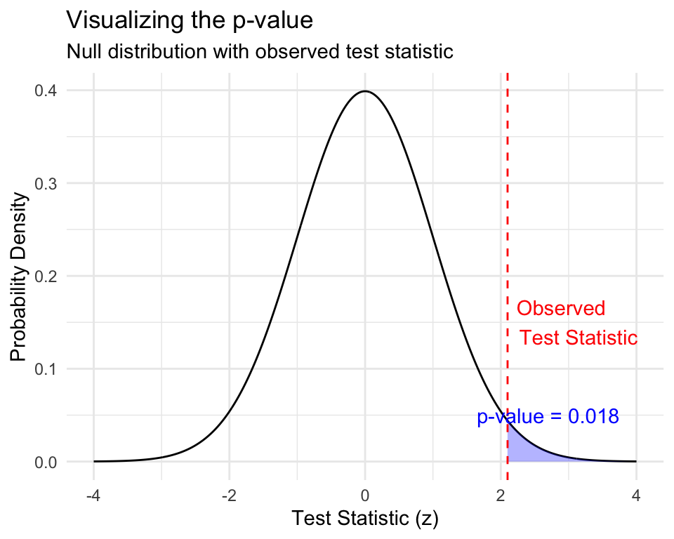

# **Lecture 4:** Type I and Type II Errors

When making decisions based on hypothesis tests, two types of errors can occur:

**Type I Error (False Positive)**

- - Rejecting H₀ when it’s actually true
- - Probability = α (significance level)
- - “Finding an effect that isn’t real”

**Type II Error (False Negative)**

- - Failing to reject H₀ when it’s actually false
- - Probability = β - “Missing an effect that is real”

**Statistical Power = 1 - β**

- - Probability of correctly rejecting a false H₀
- - Increases with:
  - - Larger sample size
  - - Larger effect size
  - - Lower variability
  - - Higher α level

# **Lecture 4:** Type I and Type II Errors

# Practice Exercise 7: Interpreting Errors and Power

**Practice Exercise 6: Interpreting P-values and Errors**

Given the following scenarios, identify whether a Type I or Type II error might have occurred:

1. A researcher concludes that a new fishing regulation increased grayling size, when in fact it had no effect.
2. A study fails to detect a real decline in grayling population due to warming water, concluding there was no effect.
3. Let’s calculate the power of our t-test to detect a 30 mm difference in length between lakes:

```r
# Calculate power for detecting a 30 mm difference
# First determine parameters
lake_I3 <- grayling_df %>% filter(lake == "I3")
lake_I8 <- grayling_df %>% filter(lake == "I8")

n1 <- nrow(lake_I3)
n2 <- nrow(lake_I8)
sd_pooled <- sqrt((var(lake_I3$length_mm) * (n1-1) +
                  var(lake_I8$length_mm) * (n2-1)) /
                  (n1 + n2 - 2))

# Calculate power
effect_size <- 30 / sd_pooled  # Cohen's d
df <- n1 + n2 - 2
alpha <- 0.05
power <- power.t.test(n = min(n1, n2),
                     delta = effect_size,
                     sd = 1,  # Using standardized effect size
                     sig.level = alpha,
                     type = "two.sample",
                     alternative = "two.sided")

# Display results
power
```

```
     Two-sample t test power calculation

              n = 66
          delta = 0.6741298
             sd = 1
      sig.level = 0.05
          power = 0.9702076
    alternative = two.sided

NOTE: n is number in *each* group
```

# **Lecture 4:** Summary

**Key concepts covered:**

1. **Probability distributions** model random phenomena
   - Normal distribution is especially important
   - Z-scores standardize measurements
2. **Standard error** measures precision of estimates
   - Decreases with larger sample sizes
   - Used to construct confidence intervals
3. **Confidence intervals** express uncertainty
   - Provide plausible range for parameters
   - 95% CI: `mean ± 1.96 × SE`
4. **Hypothesis testing** evaluates claims
   - Null vs. alternative hypotheses
   - P-values quantify evidence against H₀
   - Consider both statistical and practical significance

Back to top